# Applications of population sampling to IBNR reserving

Sebastian Calcetero, Sheldon Lin.

Department of Statistical Sciences, University of Toronto

Accurate claim reserve estimation is essential for insurance companies to ensure solvency and meet regulatory standards. Traditionally, claim reserving has relied on two main approaches: macro-level models, like the Chain-Ladder method, which estimate reserves based on aggregate data, and micro-level models, which provide more precise estimates by analyzing individual claims. While macro-level models are straightforward and widely used, they may miss specific claim-level patterns (see, e.g., Wüthrich (2018b) and Crevecoeur, Robben, and Antonio (2022)). On the other hand, micro-level models, despite their precision, require complex, data-intensive processes and remain underutilized in the industry due to their complexity (see, e.g., Taylor, McGuire, and Sullivan (2008), Antonio and Plat (2014), and Wüthrich (2018a)).

Our proposed research aims to provide a novel statistical framework for reserving, as well as to boost reserving method performance while largely preserving simplicity and interpretability. To achieve this, we propose a novel approach that treats reported claims as a sample from a broader population, similar to a population sampling problem in statistics (Särndal, Swensson, and Wretman (2003)). This framework provides methods to improve reserve accuracy and also enhances robustness by handling data variability. The approach uses advanced statistical tools like double-robust estimators and debiasing techniques, making reserve estimates more adaptable to dynamic conditions.

This report showcases how our proposed unified approach can transform claim reserving, offering a more flexible, reliable, and comprehensive framework that effectively addresses the limitations of existing methods. Our main goal is to deliver the practical implementation of our proposed approach, rather than diving deep into the theoretical insights. The report begins with two concise sections introducing the problem, notation and our approach, followed by an extensive numerical illustration using simulated data. We hope our approach empowers practitioners and actuaries to leverage their datasets at a granular level, enabling more accurate and insightful reserve calculations. For the full technicality, we refer to the aformentioned paper this report is based on.

Suppose an insurance company is evaluating its total liabilities from claims with accident times between $t=0$ and $t=\tau$, where $\tau$ is the valuation time set by the actuary. In general insurance, there is often a delay between when an accident occurs and when it is reported to the company. Then, at valuation time $\tau$, the insurer knows only the claims that have been reported and the partial amount paid to each one. Therefore the insurer aims to estimate the total amount for unreported claims to calculate the reserve for outstanding claims.

Along those lines, let us describe the claim process as follows:

The total liability for accidents occurring before $\tau$, denoted $L(\tau)$, is:
$$L(\tau) = \sum_{i=1}^{N(\tau)} Y_{i}.$$
The portion of liability known to the company by $\tau$ (from reported claims), denoted $L^R(\tau)$, is:
$$L^R(\tau) = \sum_{i=1}^{N^{R}(\tau)} Y_{i}.$$
One is interested in estimating the liability for non-reported claims, denoted $L^{IBNR}(\tau)$, which is:
$$L^{IBNR}(\tau) = L(\tau) - L^R(\tau)=\sum_{i=1}^{N^{IBNR}(\tau) } Y_i .$$

Usual stochastic reserving models focus on estimating reserves through individual claim analysis, characterizing components like the number of claims per individual, claim amounts, and reporting delays (see Antonio and Plat (2014)). These models apply flexible machine-learning methods to accurately capture data behaviors, providing point estimates $\hat{Y}_i$ for claim amounts, total claims, and non-reported claims $\hat{N}^{IBNR}(\tau)$. Reserves are then estimated by summing over the predicted quantities of nonreported claims as:

$$\sum_{i=1}^{\hat{N}^{IBNR}(\tau)} \hat{Y}_i.$$

Models for the reported claims data are fitted using maximum likelihood estimation, where the log-likelihood expression is:

$$\log f_{N^R(\tau)}(N^R(\tau)) +\sum_{i=1}^{N^R(\tau)} \left( \log f_Y(Y_{i} \mid U_i \le \tau-T_{i}, x_i)+ \log \left( \frac{f_U(U_{i}\mid Y_{i} )}{F_U(\tau-T_{i}\mid x_i, Y_{i} )} \right) \right) ,$$

where terms correspond to frequency, severity and delay, respectively.

The independence of these components, especially between severity and delay, is often assumed but may introduce bias due to the truncation of non-reported claims. This independence assumption, rarely questioned in reserving literature, contrasts with population sampling, where accounting for sampling design is crucial to avoid bias. The truncated nature of reserving data (i.e., only reported claims observed) means it may not fully represent the population if dependencies between variables exist. Consequently, failing to adjust for this can yield biased reserve estimates, as characteristics of reported claims differ from unreported ones. In response, the model-assisted approach in population sampling emphasizes adjusting for this data bias. The following section explores integrating these approaches into reserving to improve reserve estimation accuracy.

In this section, we first introduce the population sampling perspective of claim reserving, and then we highlight the key methods from such field that can be integrated into reserving practices to improve estimates, offering more flexible and robust estimates, especially when an actual reserving model is considered.

Using the population sampling point of view, we can think of a context in which we are interested in finding a population total, based only on a sample. Here, we treat all $N(\tau)$ claims as the population, and the $N^{R}(\tau)$ claims reported by the valuation date as the sample. Indeed, one can define the so-called membership indicator variable (belongs or not to the sample) for each claim is $\mathbf{1}_i(\tau) = \mathbf{1}_{ \{ R_i \le \tau \} }$, and their inclusion probabilities $\pi_i(\tau)$ given by
$$\pi_i(\tau) = P( R_i \le \tau \vert \boldsymbol{x}_i, T_i, Y_i) = P( U_i \le \tau - T_i \vert \boldsymbol{x}_i, T_i, Y_i).$$
These probabilities, which depend on valuation time and vary by claim due to differing accident types and risk profiles, are unknown and must be estimated from the data. This can be achieved by recognizing that the reporting delay time is a time-to-event random variable under a right-truncation scheme. In this case, the right-truncation problem arises as the data consists only of claims for which the reporting delay time is less than the valuation time, and we do not have record of those for which the delay is larger than the valuation time. Therefore one can use existing approaches from survival analysis to obtain an estimation of the cumulative distribution function, from which the desired inclusion probabilities can be obtained. For instance, Cox regression models are by far the most popular techniques used in survival analysis (e.g., George, Seals, and Aban (2014)) while accounting for the heterogeneity arising from the attributes as well as the righ truncation, see. e.g Vakulenko-Lagun, Mandel, and Betensky (2019). We will further illustrate this procedure in the numerical study. The important fact to keep in mind is that the estimation of the inclusion probabilities in a proper manner is a key component from the population sampling perspective.

We now proceed to describe the methods from the literature of population sampling that can be integrated into the reserving context. In general, we can informally classify these approaches in different backgrounds based on when the technique is applied with respect to the estimation of a model.

All of these approaches require as starter point the inclusion probabilities. This component is usually estimated as part of any reserving model itself, yet however, we remark again the importance of this component for which a proper estimation methodology should be used.

For what follows suppose that a reserving model is available (e.g. a frequency-severity model as described in the previous section) that provides estimates of the total number of claims, $\hat{N}(\tau)$, the total number of non-reported claims, $\hat{N}^{IBNR}(\tau)$ and each of the claim amounts, which we will denote as $\hat{Y}_i$. This information could be based on expert opinion, such as is commonly for the so-called case ultimates, or based on a so-called micro-level reserving model as in Antonio and Plat (2014).

A well-established estimator when a model is assisting is given by an augmented inverse probability weighting estimator (AIPW) estimator, also known as the difference estimator, e.g., Särndal, Swensson, and Wretman (2003), which is given by

$$\hat{L} (\tau) = \sum_{i=1}^{\hat{N}(\tau)} \hat{Y}_i + \sum_{i=1}^{N^{R}(\tau)} \frac{Y_i-\hat{Y}_i}{\pi_{i}(\tau)},$$

where the first term can be thought of as the estimation of the population total based solely on the auxiliary information $\hat{Y}_i$, and the second term can be thought of as an scaling of the “residuals,” $Y_i - \hat{Y}_i$, in the actual sample to match the population. Along those lines, an AIPW estimator of the outstanding claims is therefore
$$\hat{L}^{IBNR}(\tau) = \hat{L}(\tau)-L^R(\tau) = \sum_{i=1}^{\hat{N}^{IBNR}(\tau)} \hat{Y}_i + \sum_{i=1}^{N^{R}(\tau)} \frac{1-\pi_i(\tau)}{\pi_{i}(\tau)} (Y_i-\hat{Y}_i),$$
The AIPW estimator acts as a correction mechanism, where the second term addresses errors in the micro-level model. Thus, a key lesson from the sampling approach is that micro-level reserving models may benefit from the bias correction provided by AIPW estimators, and may provide preferable estimates. This will be further illustrated in the numerical study.

One approach to account for the sampling mechanism in the estimation of a model involves using weighted estimating equations, where the weights are the odds ratio of no inclusion vs inclusion $\frac{1-\pi_i(t)}{\pi_i(t)}$, as discussed in various studies, e.g., Wooldridge (2007) and subsequent literature. For example, consider an estimating equation for the severity model based on minimizing the empirical version of a loss function. The following weighted equation is unbiased for the loss function of the non-reported claims population:

$$\sum_{i=1}^{N^R} \frac{1-\pi_i(\tau)}{\pi_i(\tau)} l(Y_i, \theta)$$

In this case, the model parameters $\theta$ should be chosen to minimize this weighted loss function rather than the unweighted version, and therefore adress the sampling bias. This approach is well-documented in the literature on missing data and surveys with non-response Shao (2008). A recent example in insurance is Peiris et al. (2024), and in reserving, implicitly in the estimation of maximum likelihood, as discussed by Bücher and Rosenstock (2024).

A broader approach involves estimating the entire population of non-reported claims using data augmentation methods commonly employed when handling missing data. Briefly, each claim $Y_i$ in the sample is expected to appear $\frac{1-\pi_i}{\pi_i}$ times in the population of non-reported claims. Therefore, a synthetic data can be constructed by replicating each reported claim $(\mathbf{x}_i, Y_i)$ in a new dataset a total $\frac{1-\pi_i}{\pi_i}$ times. The distribution function implied on this pseudo-data set would be given by:

$$\hat{F}_Y(y) = \frac{ \sum_{i=1}^{N^R(\tau)} \frac{1-\pi_i(\tau)}{\pi_i(\tau)} \mathbf{1}_{ \{Y_i \le y\}} }{ \sum_{i=1}^{N^R(\tau)} \frac{1-\pi_i(\tau)}{\pi_i(\tau)} }.$$

which is a self-normalized IPW estimator of the CDF of the non-reported claim amounts, which is known to be a strongly consistent estimator. Therefore, this synthetic data should behave similarly to the unknown non-reported claims and can be treated as the true data, allowing for the estimation of reserves, statistical models and related quantities.

In this section, we illustrate the methods using a simulated data set developed by Wang and Wuthrich (2022) . The dataset contains individual claims for non-life insurance reserving studies, containing a range of claim-specific attributes and temporal markers. Each claim is characterized by the accident date, reporting date, and settlement date, alongside payments made over time, claim status, and various covariates such as the claimant’s age and the claim type. The dataset includes information on claims closed by a cutoff date, claims reported but not settled, and incurred but not reported (IBNR) claims that need prediction.

Key attributes include identifiers such as claim ID, accident and reporting dates in various time units (daily, monthly), reporting delay, and settlement delays. Claims have status indicators that flag them as closed, reported but unsettled (RBNS), or IBNR as of the cutoff date, with cumulative payments recorded for closed and RBNS claims. Additional features include the total claim amount (Ultimate), payment count, age of the injured, and claim types with labels 1 to 6, which may affect claim frequency and severity. Detailed payments data is also available, allowing for tracking individual payment events, which are useful for back-testing claims reserving methods on this dataset.

One has to first download the relevant files in the same working directory, in particular “functions simulation.R,” which can be accessed through the GitHub repository linked in the document: github.com/actuarial-data-science/PackageIndividualClaimsSimulator. This repository includes the R code and associated functions needed to generate and simulate individual claims data. One also must ensure to install all required dependencies, like the SynthETIC R package, which is necessary for running the simulation.

The primary function, `data.generation()`, generates the dataset. This produces a list with two objects: a dataset of individual claim details, such as claim ID, type, accident date, reporting date, and cumulative payments up to the cutoff date; and a dataset of claim payments and statuses, identifying each payment event by event month and payment status (open or closed). Below is the code to generate the data, and attributes.

```r
##Load packages
library(SynthETIC)  # 1.0.0 or higher needed
library(tidyverse)

#### generate claim data
ref_claim <- 1          # currency is 1
time_unit <- 1/24       # we consider biweekly claims development
set_parameters(ref_claim=ref_claim, time_unit=time_unit)
years <- 5               # number of occurrence years
I <- years/time_unit      # number of development periods
setwd("C:/Users/Sebastian/Downloads/PackageIndividualClaimsSimulator-main/PackageIndividualClaimsSimulator-main")
source("./Tools/functions simulation.R")

# generate individual claims: may take 60 seconds
set.seed(123456789)
claims_list <- data.generation(seed=1000, future_info=F)

# save individual output for easier access
claims <- claims_list[[1]]

# Fix format and create dates variables
claims$Month = format(claims$AccDate, "%m")
claims$Year = as.factor(format(claims$AccDate, "%y"))
claims$Type = as.factor(claims$Type)
claims$RepDelDays = claims$RepDelDays + runif(n=length(claims$RepDelDays))

#Work only with the closed claims as we consider IBNR and not RBNS
claim_payments =  claims[claims$Status=="Closed",]
str(claim_payments)
```

```
## 'data.frame':    20412 obs. of  17 variables:
##  $ Id          : int  1 2 3 4 5 6 7 8 9 10 ...
##  $ Type        : Factor w/ 6 levels "1","2","3","4",..: 2 2 4 4 5 5 1 4 1 4 ...
##  $ Age         : int  45 31 27 58 59 43 30 57 30 19 ...
##  $ AccDate     : Date, format: "2012-01-05" "2012-01-08" ...
##  $ AccMonth    : num  1 1 1 1 1 1 1 1 1 1 ...
##  $ AccWeekday  : Factor w/ 7 levels "Mon","Tue","Wed",..: 4 7 5 5 2 3 5 4 4 6 ...
##  $ RepDate     : Date, format: "2012-01-05" "2012-01-08" ...
##  $ RepMonth    : num  1 1 1 1 1 1 1 1 1 1 ...
##  $ RepDelDays  : num  0.45 0.189 1.221 2.083 12.657 ...
##  $ SetMonth    : num  62 28 48 37 25 79 22 38 21 38 ...
##  $ SetDelMonths: num  61 27 47 36 24 78 21 37 20 37 ...
##  $ Ultimate    : num  11946 27040 3829 1754 6443 ...
##  $ PayCount    : num  2 3 1 1 3 2 0 2 1 2 ...
##  $ Status      : Factor w/ 3 levels "Closed","RBNS",..: 1 1 1 1 1 1 1 1 1 1 ...
##  $ CumPaid     : num  11946 27040 3829 1754 6443 ...
##  $ Month       : chr  "01" "01" "01" "01" ...
##  $ Year        : Factor w/ 10 levels "12","13","14",..: 1 1 1 1 1 1 1 1 1 1 ...
```

```r
#Valuation date
valuation_date = as.Date("2015-02-02")

#Split data into reported and non-reported (train and test)
#Al claims in the period
all_claims = claim_payments %>% filter(AccDate<=valuation_date )

#Reported claims
reported_claims = claim_payments %>% filter(RepDate<=valuation_date,
                                            AccDate<=valuation_date )
#Not reported claims
non_reported_claims = claim_payments %>% filter(RepDate>valuation_date,
                                                AccDate<=valuation_date )
#Standing claims (i.e. reserve)
sum(non_reported_claims$Ultimate)
```

```
## [1] 13248103
```

We now proceed to illustrate the implementation of the sampling approach along with the reserving methods in order to estimate this amount. To do so we first require the estimation of the inclusion probabilities, which are obtained via the distribution of the reporting delay as described as follows.

We selected a Cox regression model that describes the hazard function of the reporting delay time, $\lambda_{U \vert \boldsymbol{x} }(u)$, using the attributes of the policyholder $\boldsymbol{x}$ as covariates, as follows:

$$\log( \lambda_{U} (u) ) = \log(\lambda_0(u)) +\beta_1\mathrm{ClaimType}+\beta_2\mathrm{Age}+\beta_3Y+\beta_4\mathrm{AccidentDay}+\beta_5\mathrm{AccidentMonth}+\beta_6\mathrm{AccidentYear}$$
where log of the baseline hazard function, $\log(\lambda_0(u))$, is estimated using a B-Spline representation. The fitting is via a generalized additive models with a piecewise exponential that accounts for right-truncation, accessible in the package as follows:

```r
#calculate truncation time variable (Valuation date-Accident date)
reported_claims$Truncation = as.numeric(valuation_date - reported_claims$AccDate+1)

#Fit the model
library("flexsurv")
fit = flexsurvspline(Surv(RepDelDays) ~ Type+Age+Ultimate+AccWeekday+Month+Year,
                     data = reported_claims,
                     rtrunc = Truncation ) #Estimation with right truncation.
#visualize results
fit
```

```
## Call:
## flexsurvspline(formula = Surv(RepDelDays) ~ Type + Age + Ultimate +
##     AccWeekday + Month + Year, data = reported_claims, rtrunc = Truncation)
##
## Estimates:
##                data mean  est        L95%       U95%       se         exp(est)
## gamma0                NA  -5.88e+00  -6.06e+00  -5.69e+00   9.42e-02         NA
## gamma1                NA   9.78e-01   9.59e-01   9.98e-01   9.98e-03         NA
## Type2           4.94e-02   6.96e-02  -7.79e-02   2.17e-01   7.53e-02   1.07e+00
## Type3           3.93e-02   2.75e-03  -1.32e-01   1.37e-01   6.87e-02   1.00e+00
## Type4           2.97e-01  -1.60e-02  -8.05e-02   4.86e-02   3.30e-02   9.84e-01
## Type5           1.33e-01  -1.94e-02  -1.04e-01   6.52e-02   4.32e-02   9.81e-01
## Type6           1.66e-01  -2.84e-02  -1.05e-01   4.81e-02   3.90e-02   9.72e-01
## Age             4.19e+01   8.15e-04  -1.03e-03   2.66e-03   9.40e-04   1.00e+00
## Ultimate        8.12e+03   4.00e-06  -3.81e-05   4.61e-05   2.15e-05   1.00e+00
## AccWeekdayTue   1.41e-01   1.02e-03  -9.34e-02   9.54e-02   4.82e-02   1.00e+00
## AccWeekdayWed   1.47e-01  -5.90e-02  -1.53e-01   3.47e-02   4.78e-02   9.43e-01
## AccWeekdayThu   1.44e-01  -5.89e-02  -1.53e-01   3.50e-02   4.79e-02   9.43e-01
## AccWeekdayFri   1.45e-01  -3.32e-03  -9.69e-02   9.02e-02   4.77e-02   9.97e-01
## AccWeekdaySat   1.36e-01  -5.61e-02  -1.51e-01   3.90e-02   4.85e-02   9.45e-01
## AccWeekdaySun   1.43e-01  -4.60e-02  -1.40e-01   4.81e-02   4.80e-02   9.55e-01
## Month02         9.52e-02   5.95e-02  -5.57e-02   1.75e-01   5.88e-02   1.06e+00
## Month03         9.76e-02   1.17e-02  -1.03e-01   1.26e-01   5.83e-02   1.01e+00
## Month04         9.24e-02   1.70e-01   5.43e-02   2.85e-01   5.88e-02   1.18e+00
## Month05         9.51e-02   1.70e-01   5.60e-02   2.85e-01   5.84e-02   1.19e+00
## Month06         8.41e-02   2.08e-01   9.01e-02   3.27e-01   6.04e-02   1.23e+00
## Month07         7.67e-02   2.97e-01   1.75e-01   4.18e-01   6.20e-02   1.35e+00
## Month08         7.53e-02   3.60e-01   2.38e-01   4.83e-01   6.25e-02   1.43e+00
## Month09         7.06e-02   4.52e-01   3.27e-01   5.76e-01   6.36e-02   1.57e+00
## Month10         6.57e-02   4.62e-01   3.34e-01   5.89e-01   6.51e-02   1.59e+00
## Month11         6.98e-02   4.12e-01   2.86e-01   5.38e-01   6.41e-02   1.51e+00
## Month12         7.32e-02   4.77e-01   3.52e-01   6.02e-01   6.37e-02   1.61e+00
## Year13          3.57e-01   3.70e-01   3.11e-01   4.28e-01   2.99e-02   1.45e+00
## Year14          2.25e-01   1.18e+00   1.11e+00   1.25e+00   3.61e-02   3.26e+00
## Year15          3.96e-03   3.50e+00   3.09e+00   3.91e+00   2.08e-01   3.30e+01
##                L95%       U95%
## gamma0                NA         NA
## gamma1                NA         NA
## Type2           9.25e-01   1.24e+00
## Type3           8.76e-01   1.15e+00
```

[output cut: 15 more lines]

```
## Month06         1.09e+00   1.39e+00
## Month07         1.19e+00   1.52e+00
## Month08         1.27e+00   1.62e+00
## Month09         1.39e+00   1.78e+00
## Month10         1.40e+00   1.80e+00
## Month11         1.33e+00   1.71e+00
## Month12         1.42e+00   1.83e+00
## Year13          1.36e+00   1.53e+00
## Year14          3.04e+00   3.50e+00
## Year15          2.19e+01   4.97e+01
##
## N = 6816,  Events: 6816,  Censored: 0
## Total time at risk: 1363016
## Log-likelihood = -41887, df = 29
## AIC = 83833
```

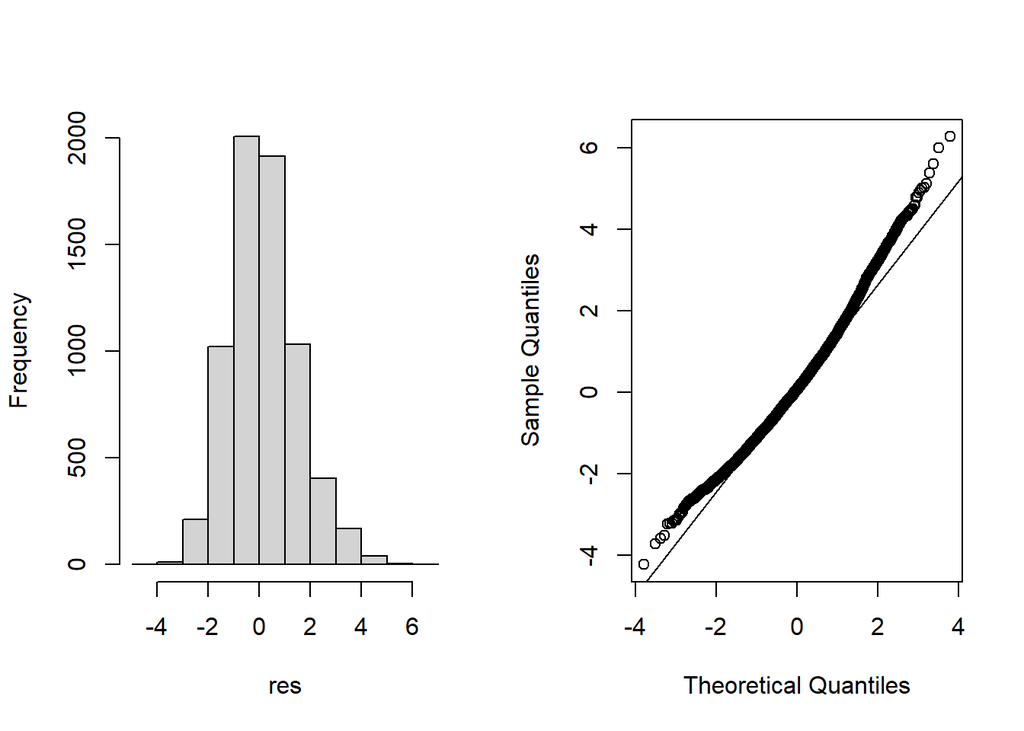

```r
#Predict inclusion prob and pseudo residuals
#We divide and predcit on groups, to make the calculation less expensive
K= 100 #
indexes = 1:length(reported_claims$RepDelDays)
split_indices <- split(indexes, cut(indexes, K, labels = FALSE))

#Vectors that store the values of the inclusion probabilities and the residuals
probs= numeric(0)
residuals = numeric(0)

for (i in 1:K ){
#Predict probabilities
a = predict(fit,type = "survival",
            times = reported_claims[split_indices[[i]],]$Truncation,
            newdata = reported_claims[split_indices[[i]],] )
b = predict(fit,type = "survival",
            times = reported_claims[split_indices[[i]],]$RepDelDays,
            newdata = reported_claims[split_indices[[i]],] )
#Concatenate
probs = rbind(probs,
              cbind(split_indices[[i]],a$.pred[[1]]) )
residuals = rbind(residuals,
                  cbind(split_indices[[i]],b$.pred[[1]]) )
}


#GOF Residual analysis
#Adjust residuals based on truncation probs and normal quantile
res = qnorm((1-residuals$.pred_survival)/(1-probs$.pred_survival))

#Plot them
par(mfrow = c(1, 2))
hist(res, main= "")
qqnorm(res, main= " " )
qqline(res)
```

We illustrate the sampling methods along with a micro-level model. We first describe a simplsitic micro-level model for this data, and fit it without using directly the population sampling based methods.

For the frequency, as we do not have the overall portfolio of policyholders but only the reported claims, we estimate a model using pseudo observations of the nonreported claims, which are constructed via the IPW estimate of the number of non-reported claims, $\frac{1-\pi_i(\tau)}{\pi_i(\tau)}$. This gives a model with the predictive rate for the number of non reported claims per number of reported claims of a given type. Statistically, this approach with pseudo observations is in spirit the same as the one from an EM algorithm, but we will not further elaborate on this.

For illustration, consider a Poisson regression model as follows. Note that this can be fitted using the glm function as follows.

$$N_i^{IBNR}(\tau) \sim \textrm{Poisson}(\lambda_i)$$
$$\log(\lambda_i) = \beta_0+\beta_1\mathrm{ClaimType}+\beta_2\mathrm{Age}+\beta_3\mathrm{AccidentDay}+\beta_4\mathrm{AccidentMonth}+\beta_5\mathrm{AccidentYear}$$

```r
#Proxy for non-reported frequency
reported_claims$N_IBNR =probs$.pred_survival/(1-probs$.pred_survival)

#Fit frequency model
fit_freq = glm(formula = N_IBNR ~ Type+Age+AccWeekday+Month+Year,
               family = poisson,
               data = reported_claims)
#Predict frequency
predicted_freq=predict(fit_freq,
                       type = "response")
#Summarize the model
summary(fit_freq)
```

```
##
## Call:
## glm(formula = N_IBNR ~ Type + Age + AccWeekday + Month + Year,
##     family = poisson, data = reported_claims)
##
## Deviance Residuals:
##    Min      1Q  Median      3Q     Max
## -2.635  -0.234  -0.015   0.166   4.586
##
## Coefficients:
##                Estimate Std. Error z value Pr(>|z|)
## (Intercept)   -4.571363   0.207648  -22.01  < 2e-16 ***
## Type2         -0.051003   0.144476   -0.35  0.72407
## Type3          0.132385   0.135410    0.98  0.32824
## Type4          0.093108   0.075657    1.23  0.21845
## Type5          0.283368   0.092609    3.06  0.00221 **
## Type6         -0.038229   0.088153   -0.43  0.66454
## Age           -0.000125   0.002150   -0.06  0.95353
## AccWeekdayTue -0.236417   0.106008   -2.23  0.02574 *
## AccWeekdayWed -0.073760   0.102375   -0.72  0.47123
## AccWeekdayThu -0.167640   0.105032   -1.60  0.11047
## AccWeekdayFri -0.192253   0.103020   -1.87  0.06202 .
## AccWeekdaySat -0.367805   0.107429   -3.42  0.00062 ***
## AccWeekdaySun -0.112256   0.099432   -1.13  0.25891
## Month02        1.354132   0.146961    9.21  < 2e-16 ***
## Month03        1.019078   0.188644    5.40  6.6e-08 ***
## Month04        1.008567   0.190729    5.29  1.2e-07 ***
## Month05        1.081507   0.185369    5.83  5.4e-09 ***
## Month06        1.171987   0.191149    6.13  8.7e-10 ***
## Month07        1.482833   0.185408    8.00  1.3e-15 ***
## Month08        1.680618   0.180069    9.33  < 2e-16 ***
## Month09        1.921810   0.175628   10.94  < 2e-16 ***
## Month10        2.065882   0.172003   12.01  < 2e-16 ***
## Month11        2.332177   0.170011   13.72  < 2e-16 ***
## Month12        2.547152   0.168291   15.14  < 2e-16 ***
## Year13         0.727039   0.106679    6.82  9.4e-12 ***
## Year14         2.363186   0.094851   24.91  < 2e-16 ***
## Year15         6.670898   0.168271   39.64  < 2e-16 ***
## ---
## Signif. codes:  0 '***' 0.001 '**' 0.01 '*' 0.05 '.' 0.1 ' ' 1
##
## (Dispersion parameter for poisson family taken to be 1)
##
##     Null deviance: 3630.06  on 6815  degrees of freedom
## Residual deviance:  991.64  on 6789  degrees of freedom
## AIC: Inf
##
## Number of Fisher Scoring iterations: 5
```

For the severity, we note that some claims may lead to no payment at all. As such, we use a Tweddie distribution as described follows. Note that this can also be fitted easily with the glm package as follows.
$$Y_i \sim \textrm{Tweedie}(\mu_i, p)$$
$$\log(\mu_i) = \beta_0+\beta_1\mathrm{ClaimType}+\beta_2\mathrm{Age}+\beta_3\mathrm{AccidentDay}+\beta_4\mathrm{AccidentMonth}+\beta_5\mathrm{AccidentYear}$$

```r
library(statmod) #Has Tweedie distribution

#Fit severity model
fit_sev = glm(formula = Ultimate ~ Type+Age+AccWeekday+Month+Year,
              family= tweedie(link="log"),
              data = reported_claims)
#Predict values
predicted_sev=predict(fit_sev,
                      type = "response")
#Summarize results
summary(fit_sev)
```

```
##
## Call:
## glm(formula = Ultimate ~ Type + Age + AccWeekday + Month + Year,
##     family = tweedie(link = "log"), data = reported_claims)
##
## Deviance Residuals:
##    Min      1Q  Median      3Q     Max
## -52507   -3898   -1768    1649  275821
##
## Coefficients:
##                Estimate Std. Error t value Pr(>|t|)
## (Intercept)    8.400792   0.083791  100.26  < 2e-16 ***
## Type2          2.068574   0.050490   40.97  < 2e-16 ***
## Type3          0.453415   0.099184    4.57  4.9e-06 ***
## Type4         -0.604514   0.102505   -5.90  3.9e-09 ***
## Type5          0.771170   0.059966   12.86  < 2e-16 ***
## Type6         -0.387238   0.108819   -3.56  0.00038 ***
## Age            0.006432   0.000958    6.71  2.1e-11 ***
## AccWeekdayTue  0.083967   0.046707    1.80  0.07226 .
## AccWeekdayWed  0.061759   0.048959    1.26  0.20719
## AccWeekdayThu  0.005145   0.049003    0.10  0.91639
## AccWeekdayFri  0.112244   0.045992    2.44  0.01469 *
## AccWeekdaySat -0.010668   0.052750   -0.20  0.83974
## AccWeekdaySun  0.055143   0.049301    1.12  0.26339
## Month02        0.012809   0.056791    0.23  0.82156
## Month03       -0.124948   0.063706   -1.96  0.04988 *
## Month04        0.006786   0.057313    0.12  0.90575
## Month05       -0.182957   0.070241   -2.60  0.00921 **
## Month06       -0.012272   0.065991   -0.19  0.85248
## Month07       -0.220978   0.072909   -3.03  0.00245 **
## Month08        0.133728   0.055057    2.43  0.01517 *
## Month09        0.073201   0.065957    1.11  0.26712
## Month10       -0.014423   0.065937   -0.22  0.82685
## Month11        0.158102   0.057697    2.74  0.00616 **
## Month12        0.226149   0.055529    4.07  4.7e-05 ***
## Year13        -0.030494   0.030162   -1.01  0.31204
## Year14         0.015982   0.034479    0.46  0.64301
## Year15        -0.006777   0.241226   -0.03  0.97759
## ---
## Signif. codes:  0 '***' 0.001 '**' 0.01 '*' 0.05 '.' 0.1 ' ' 1
##
## (Dispersion parameter for Tweedie family taken to be 1.9e+08)
##
##     Null deviance: 1.9739e+12  on 6815  degrees of freedom
## Residual deviance: 1.2902e+12  on 6789  degrees of freedom
## AIC: NA
##
## Number of Fisher Scoring iterations: 9
```

We can therefore combine these two components to provide an estimate of the reserve using the model fitted on the pre-processing:

```r
#Predict reserve: IBNR frequency x severity
ML = sum(predicted_freq*predicted_sev)
ML
```

```
## [1] 10809767
```

We now proceed to illustrate how such working model can be adjusted with the use of the population sampling techniques.

For the post processing we illustrate the use of the AIPW estimator. This can easily implemented once the micro-level model has been fitted as suaul.

```r
#Estimate IPW weights
reported_claims$Weight =probs$.pred_survival/(1-probs$.pred_survival)

#Calculate augmentation term and AIPW
error_term = sum((reported_claims$CumPaid-predicted_sev)*reported_claims$Weight)
AIPW = ML+error_term

#Display results
cbind(ML_model = ML,
      Augmentation_term =error_term,
      AIPW = AIPW)
```

```
##      ML_model Augmentation_term     AIPW
## [1,] 10809767           1387960 12197727
```

For the in-processing approach we consider the same micro-level model, but this is fitted using weighted estimating equations instead. In this case, for the glm, we fit an alternative severity model but using a weighted maximum likelihood approach.

```r
#Fit severity model using weighted likelihood
fit_sev_wl = glm(formula = Ultimate ~ Type+Age+AccWeekday+Month+Year,
              family= tweedie(link="log"),
              data = reported_claims,
              weights = Weight)

#Predict values
predicted_sev_wl = predict(fit_sev_wl,
                      type = "response")

#Summarize estimation
summary(fit_sev_wl)
```

```
##
## Call:
## glm(formula = Ultimate ~ Type + Age + AccWeekday + Month + Year,
##     family = tweedie(link = "log"), data = reported_claims, weights = Weight)
##
## Deviance Residuals:
##    Min      1Q  Median      3Q     Max
## -57409    -948    -100     697  140525
##
## Coefficients:
##               Estimate Std. Error t value Pr(>|t|)
## (Intercept)    7.57037    0.11625   65.12  < 2e-16 ***
## Type2          2.39560    0.06869   34.87  < 2e-16 ***
## Type3         -0.23497    0.17452   -1.35  0.17821
## Type4         -0.50533    0.13245   -3.82  0.00014 ***
## Type5          1.29141    0.06820   18.94  < 2e-16 ***
## Type6          1.09129    0.06962   15.67  < 2e-16 ***
## Age            0.00800    0.00113    7.09  1.5e-12 ***
## AccWeekdayTue  0.47904    0.05073    9.44  < 2e-16 ***
## AccWeekdayWed  0.29396    0.06437    4.57  5.0e-06 ***
## AccWeekdayThu  0.13830    0.06682    2.07  0.03851 *
## AccWeekdayFri  0.57777    0.05917    9.76  < 2e-16 ***
## AccWeekdaySat  0.11569    0.06910    1.67  0.09417 .
## AccWeekdaySun  0.89427    0.04533   19.73  < 2e-16 ***
## Month02       -0.54585    0.06401   -8.53  < 2e-16 ***
## Month03       -0.05083    0.07862   -0.65  0.51792
## Month04       -0.10565    0.08135   -1.30  0.19410
## Month05       -0.27463    0.09088   -3.02  0.00252 **
## Month06       -0.35845    0.10961   -3.27  0.00108 **
## Month07       -0.42564    0.09243   -4.60  4.2e-06 ***
## Month08        0.10238    0.06648    1.54  0.12362
## Month09       -0.41975    0.10395   -4.04  5.4e-05 ***
## Month10       -0.20821    0.06952   -3.00  0.00275 **
## Month11       -0.37691    0.08432   -4.47  8.0e-06 ***
## Month12        0.28942    0.06063    4.77  1.8e-06 ***
## Year13         0.10597    0.05438    1.95  0.05140 .
## Year14         0.07516    0.05009    1.50  0.13351
## Year15         0.75500    0.07095   10.64  < 2e-16 ***
## ---
## Signif. codes:  0 '***' 0.001 '**' 0.01 '*' 0.05 '.' 0.1 ' ' 1
##
## (Dispersion parameter for Tweedie family taken to be 4e+07)
##
##     Null deviance: 4.3335e+11  on 6815  degrees of freedom
## Residual deviance: 2.7372e+11  on 6789  degrees of freedom
## AIC: NA
##
## Number of Fisher Scoring iterations: 17
```

The fitted model display similarities with the previous fitted model for the severity (which was fitted using the data of reported claims without any adjustments), yet there are some considerable differences in the estimated parameters. This illustrates the diffent behavior in the claim severity between the two populations.

We can therefore combine the frequency model with the alternative severity model to provide an estimate of the reserve:

```r
#Predict reserve: IBNR frequency x severity
ML_WL = sum(predicted_freq*predicted_sev_wl)
ML_WL
```

```
## [1] 11713328
```

While one can use the weights $\frac{1-\pi_i(\tau)}{\pi_i(\tau)}$ for the number of repetition, we create the synthetic data set of non-reported claims by generating realizations of weights according to a geometric distribution with success probability equal to the inclusion probability. This accounts for randomness in the data generation process. To illustrate the similarities of the synthetic non-reported claims and the real non-reported claims, we observe that the CDF of the distribution of the claim amount from the synthetic data set resembles considerably the one of the true non reported claims data.

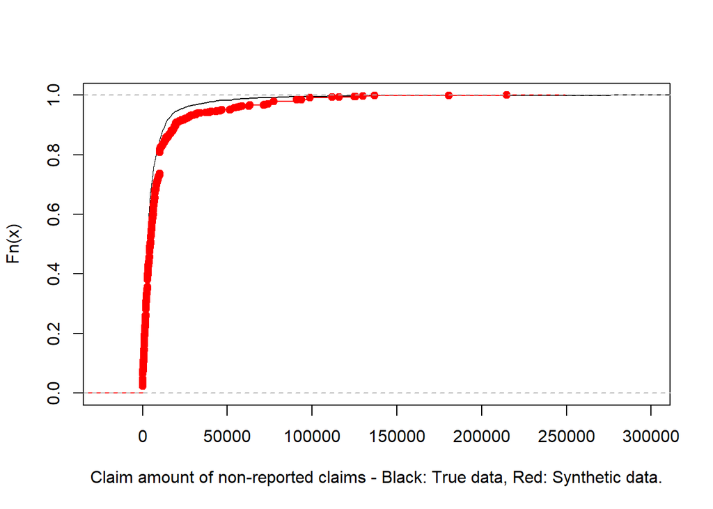

```r
#Create data set of synthetic claims
synthetic_non_reported = reported_claims %>%
                         mutate(Rcount = rgeom(n= length(reported_claims$Ultimate),
                                               prob = 1-probs$.pred_survival )) %>%
                         uncount(weights = Rcount)

#Distribution of the non-reported claims
ecdf_nr = ecdf(non_reported_claims$Ultimate)

#Distribution of the synthetic non-reported claims
ecdf_s = ecdf(synthetic_non_reported$Ultimate)

#Plot distributions
plot(ecdf_nr, main=" ",
     xlab= "Claim amount of non-reported claims - Black: True data, Red: Synthetic data.")
lines(ecdf_s, col="red")
```

Lastly, note that while we could directly fit the mcirolevel model on this data and have another prediction, we remark that the pre-processing approach leads automatically to an estimate of the reserve by directly using the total amount from the synthetic data. We focus on the latter approach to illustrate the versatility of the methodology.

```r
#Using the synthetic data set we can estimate the reserve right away
SYN = sum(synthetic_non_reported$Ultimate)
SYN
```

```
## [1] 13347650
```

The summary of the results are illustrated in the table below.

```r
# True value and point estimates
true_value <- sum(non_reported_claims$Ultimate)
point_estimates <- c(true_value,ML, AIPW,ML_WL, SYN)
methods <- c("True value","Micro Level", "AIPW", "Weighted", "Synthetic")

# Create a data frame to hold the information
comparison_table <- data.frame(
  Method = as.character(methods),
  Estimate = point_estimates,
  Error = point_estimates - true_value,
  Percent_Error = (point_estimates - true_value) / true_value * 100
)

print(comparison_table)
```

```
##        Method Estimate    Error Percent_Error
## 1  True value 13248103        0          0.00
## 2 Micro Level 10809767 -2438336        -18.41
## 3        AIPW 12197727 -1050376         -7.93
## 4    Weighted 11713328 -1534775        -11.58
## 5   Synthetic 13347650    99547          0.75
```

To face this issue, this paper introduces a novel viewpoint to claim reserving by applying principles from population sampling theory, specifically through the use of the augmented inverse probability weighting (AIPW) estimator. The key theoretical contribution of this work is that the AIPW estimator integrates the aggregate perspective of macro-level models with the detailed insights of micro-level models, offering a unified statistical framework that enhances both the robustness and accuracy of reserve estimates. Adopting a population sampling perspective also offers a new understanding of the reserving process, emphasizing the importance of population unbiasedness in tailoring reserving models. This perspective presents a practical and theoretically sound method for combining the strengths of macro and micro-level approaches while integrating other statistical techniques to address the diverse challenges posed by claim behaviors. Specifically, the use of augmentation terms for correction, weighted balance properties, and alternative weighted estimation equation for model estimation has the potential to improve reserve estimation for a given reserving model.

Future research could explore other sampling-based methods and their applications to reserving problems. For example, alternative techniques designed for missing data or those from causal inference contexts may offer valuable insights. Additionally, there is potential to improve samplimng motivated methodologies beyond those discussed in this paper. Specifically, the process of adjusting model predictions based on observed errors in reported claims aligns with Bayesian approaches using posterior distributions. Thus, incorporating Bayesian models into claim reserving may provide an interesting and valuable perspective.

Antonio, Katrien, and Richard Plat. 2014. “Micro-Level Stochastic Loss Reserving for General Insurance.” *Scandinavian Actuarial Journal* 2014 (7): 649–69.

Bücher, Axel, and Alexander Rosenstock. 2024. “Combined Modelling of Micro-Level Outstanding Claim Counts and Individual Claim Frequencies in Non-Life Insurance.” *European Actuarial Journal*, 1–33.

Crevecoeur, Jonas, Jens Robben, and Katrien Antonio. 2022. “A Hierarchical Reserving Model for Reported Non-Life Insurance Claims.” *Insurance: Mathematics and Economics* 104: 158–84.

George, Brandon, Samantha Seals, and Inmaculada Aban. 2014. “Survival Analysis and Regression Models.” *Journal of Nuclear Cardiology* 21 (4): 686–94.

Peiris, Hashan, Himchan Jeong, Jae-Kwang Kim, and Hangsuck Lee. 2024. “Integration of Traditional and Telematics Data for Efficient Insurance Claims Prediction.” *ASTIN Bulletin: The Journal of the IAA* 54 (2): 263–79.

Särndal, Carl-Erik, Bengt Swensson, and Jan Wretman. 2003. *Model Assisted Survey Sampling*. Springer Science & Business Media.

Shao, Jun. 2008. *Mathematical Statistics*. Springer Science & Business Media.

Taylor, Greg, Gráinne McGuire, and James Sullivan. 2008. “Individual Claim Loss Reserving Conditioned by Case Estimates.” *Annals of Actuarial Science* 3 (1-2): 215–56.

Vakulenko-Lagun, Bella, Micha Mandel, and Rebecca A. Betensky. 2019. “Inverse Probability Weighting Methods for Cox Regression with Right-Truncated Data.” *Biometrics* 76 (2): 484–95. https://doi.org/10.1111/biom.13162.

Wang, Melantha, and Mario V Wuthrich. 2022. “Individual Claims Generator for Claims Reserving Studies: Data Simulation. r.” *R (June 3, 2022). UNSW Business School Research Paper Forthcoming*.

Wooldridge, Jeffrey M. 2007. “Inverse Probability Weighted Estimation for General Missing Data Problems.” *Journal of Econometrics* 141 (2): 1281–301.

Wüthrich, Mario V. 2018a. “Machine Learning in Individual Claims Reserving.” *Scandinavian Actuarial Journal* 2018 (6): 465–80.

———. 2018b. “Neural Networks Applied to Chain–Ladder Reserving.” *European Actuarial Journal* 8: 407–36.